# Exponential Distribution

## Simulate data

Per the assignment, set lambda equal to .2. We will then simulate 1000 n=40 samples and take the mean of each. This will be stored in a vector called “means”

```r
lambda <- .2
n <- 40
nosim <- 1000
means <- NULL

for (i in 1:1000) {
        means[i] <- mean(rexp(n, lambda))
}
```

## Explore the data

### 1. Show where the distribution is centered at and compare it to the theoretical center of the distribution.

The distribution is centered at:

```r
mean(means)
```

```
## [1] 4.998
```

The theoretical center is $1/\lambda$ which is:

```r
1/lambda
```

```
## [1] 5
```

### 2. Show how variable it is and compare it to the theoretical variance of the distribution.

Because the Central Limit Thoerim applies, the theoretical variance is $\sigma^2 / n$

Using this, we can compare the distribution variance:

```r
var(means)
```

```
## [1] 0.6427
```

To the theoretical variance:

```r
((1/lambda)^2)/n
```

```
## [1] 0.625
```

### 3. Show that the distribution is approximately normal.

We can use qqnorm to test for a normality. qqnorm per it’s description produces a normal QQ plot of the values in y. qqline adds a line to a “theoretical”, by default normal, quantile-quantile plot which passes through the probs quantiles, by default the first and third quartiles.

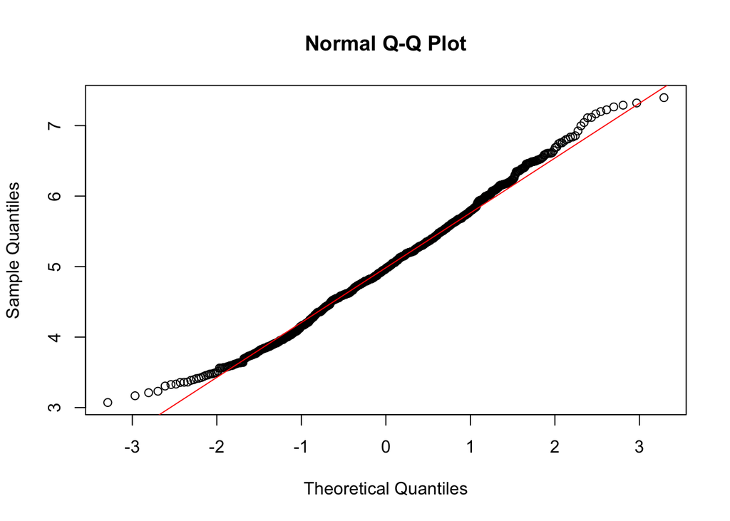

```r
qqnorm(y=means); qqline(y=means, col=2)
```

As you can see, the values are very close to a normal distribution

### 4. Evaluate the coverage of the confidence interval for $1/\lambda: \bar X \pm 1.96 * S /\sqrt{n}$

```r
s <- sd(means)
mean(means) + c(-1,1) * 1.96* s/sqrt(length(means))
```

```
## [1] 4.948 5.048
```

As you can see above, the averages of 1000 sample distributions has a 95% chance of containing the population mean of 5. In this case it does contain it.